# COVID19 Epi Dynamics In Prisons

Chris Hoover

1/11/2021

# Description

Analyzing COVID-19 dynamics in carceral facilities. Data come from the [UCLA Law Covid Behind Bars project](https://github.com/uclalawcovid19behindbars/data) which scrapes data from [CA Dept of Corrections and Rehabilitation](https://www.cdcr.ca.gov/covid19/population-status-tracking/) and other websites. Goals here include developing a general understanding of COVID19 dynamics in carceral facilities, estimating $\mathcal{R}$, and quantifying the impact of any interventions aimed at reducing spread in these facilities.

# Data

## Cases

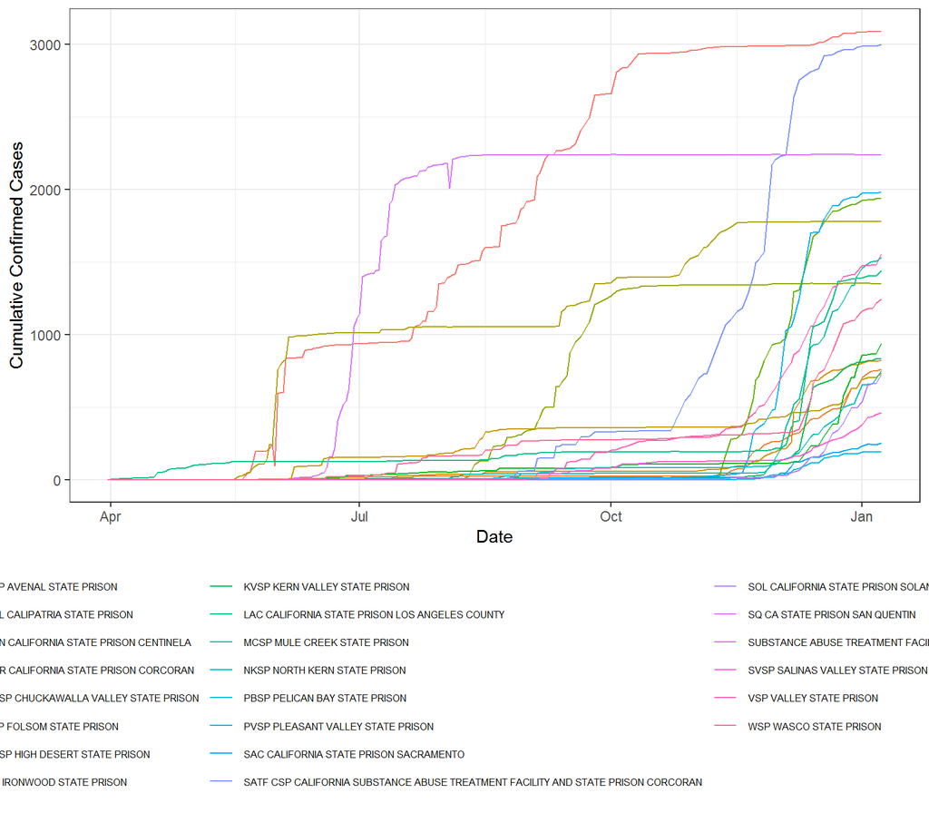

Cumulative cases among residents as reported directly by cdcr

```r
uclabb_sps %>%
  ggplot() +
    theme_bw() +
    theme(legend.position = "bottom",
          legend.text = element_text(size = 6)) +
    guides(col = guide_legend(ncol = 3)) +
    geom_line(aes(x = Date, y = Residents.Confirmed, col = Name)) +
    labs(x = "Date", y = "Cumulative Confirmed Cases")
```

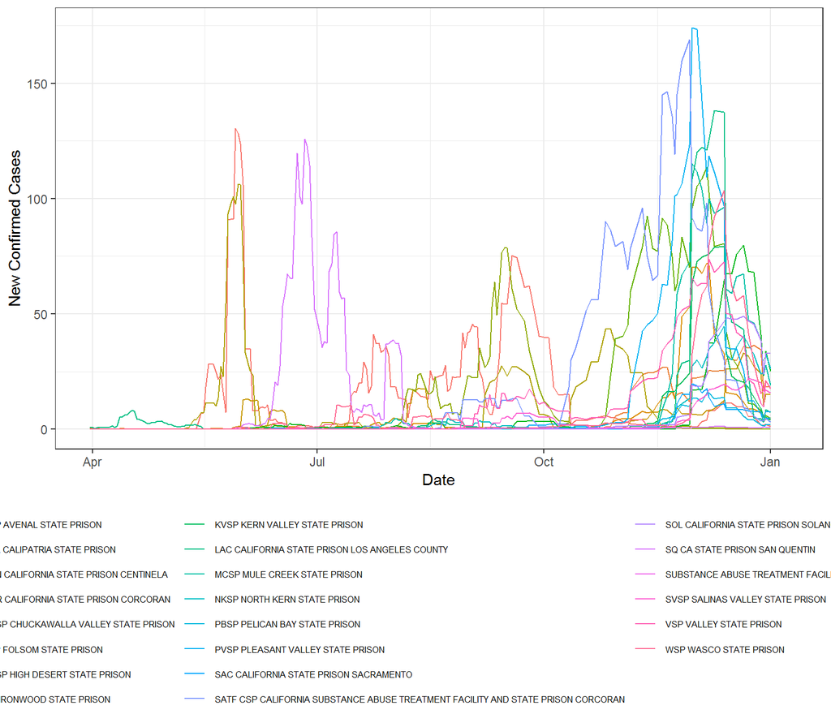

New confirmed cases among residents estimated as daily change in reported cumuative cases. Negative values replaced with NA and then 7-day smoothing window applied

```r
uclabb_sps %>%
  group_by(Name) %>%
  mutate(
    new_res_cases_rmv_neg = if_else(new_residents_confirmed < 0,
                                    NA_real_,
                                    new_residents_confirmed),
    new_cases_res_smooth = zoo::rollapply(data = new_res_cases_rmv_neg,
                                          width = 7,
                                          FUN = mean,
                                          na.rm = T,
                                          fill = NA,
                                          align = "left")
  ) %>% #View()
  ggplot() +
    geom_line(aes(x = Date, y = new_cases_res_smooth, col = Name)) +
    theme_bw() +
    theme(legend.position = "bottom",
          legend.text = element_text(size = 6)) +
    guides(col = guide_legend(ncol = 3)) +
    labs(x = "Date", y = "New Confirmed Cases")
```

Obviously a few data errors as there should never be negative values. Likely from reporting quirks in the cumulative case counts (e.g. report new rather than cumulative). Will switch to weekly reports to match population data below.

## Population

Population data for state facilities scraped and processed from https://www.cdcr.ca.gov/research/weekly-total-population-report-archive-2020/ (see `data/get/*_cdcr_pop_pdfs.R`)

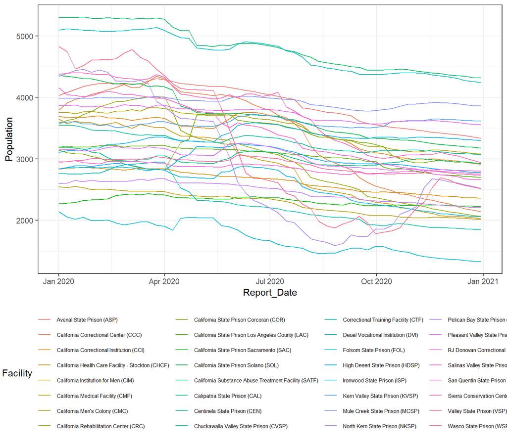

Population data for CA State carceral facilities through 2020

```r
pop_sps <- readRDS("data/derived/cdcr_population_ts_2020-01-11.rds") %>%
  mutate(dplyr::across(.cols = c("Capacity", "Design_Capacity", "Percent_Occupied", "Staffed_Capacity"),
                .fns = as.numeric))

pop_dates <- unique(pop_sps$Report_Date)

pop_sps %>%
  filter(Facility_Type == "Male Institution") %>%
  ggplot() +
    geom_line(aes(x = Report_Date, y = Capacity, col = Facility)) +
    theme_bw() +
    theme(legend.position = "bottom",
          legend.text = element_text(size = 6)) +
    guides(col = guide_legend(ncol = 4)) +
    labs(y = "Population")
```

General decline in population, but also evidence of some rapid intentional depopulation in some facilities.

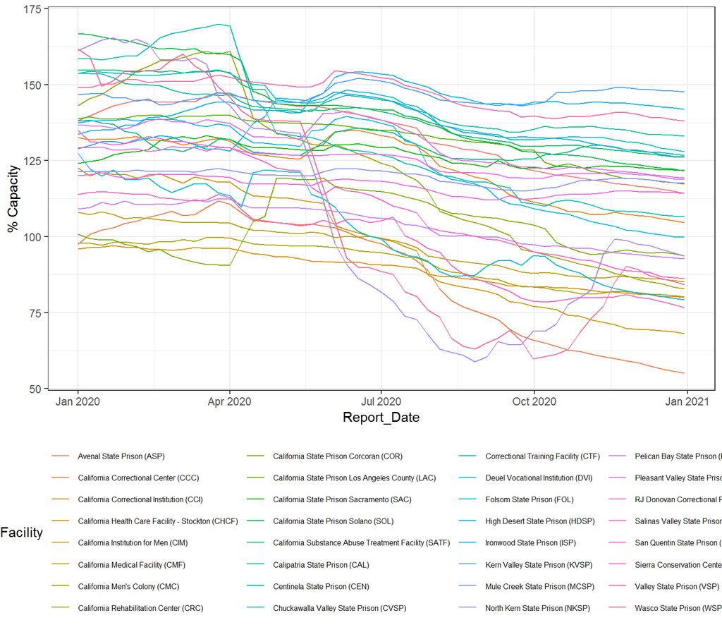

% occupied capacity for CA State carceral facilities through 2020

```r
pop_sps %>%
  filter(Facility_Type == "Male Institution") %>%
  ggplot() +
    geom_line(aes(x = Report_Date, y = Percent_Occupied, col = Facility)) +
    theme_bw() +
    theme(legend.position = "bottom",
          legend.text = element_text(size = 6)) +
    guides(col = guide_legend(ncol = 4)) +
    labs(y = "% Capacity")
```

## Merge Pop and Cases for state facilities

```r
# First generate lookup table to merge the two datasets ----------------
pop_facs <- unique(pop_sps$Facility)
case_facs <- unique(uclabb$Name)

facility_lookup_table <- data.frame(Facility_pop = pop_facs,
                                    Facility_case = NA)

# Match 3/4 letter codes for facilities
for(i in 1:length(facility_lookup_table$Facility_pop)){
  fac_code <- gsub(".*\\((.*)\\).*", "\\1", facility_lookup_table$Facility_pop[i])

  init_grep <- grepl(fac_code, case_facs)

  if(sum(init_grep) == 1){
    fac_case <- case_facs[which(init_grep)]
  } else {
    fac_case <- sum(init_grep)
  }

  facility_lookup_table$Facility_case[i] <- fac_case
}

# Above works for most, but some require manual assignment
facility_lookup_table$Facility_case[which(facility_lookup_table$Facility_pop == "Calipatria State Prison (CAL)")] <- "CAL CALIPATRIA STATE PRISON"
facility_lookup_table$Facility_case[which(facility_lookup_table$Facility_pop == "Centinela State Prison (CEN)")] <- "CEN CALIFORNIA STATE PRISON CENTINELA"
facility_lookup_table$Facility_case[which(facility_lookup_table$Facility_pop == "California Health Care Facility - Stockton (CHCF)")] <- "CALIFORNIA HEALTH CARE FACILITY CHCF STOCKTON"
facility_lookup_table$Facility_case[which(facility_lookup_table$Facility_pop == "California State Prison Corcoran (COR)")] <- "COR CALIFORNIA STATE PRISON CORCORAN"
facility_lookup_table$Facility_case[which(facility_lookup_table$Facility_pop == "California Rehabilitation Center (CRC)")] <- "CRC CALIFORNIA REHABILITATION CENTER"
facility_lookup_table$Facility_case[which(facility_lookup_table$Facility_pop == "Ironwood State Prison (ISP)")] <- "ISP IRONWOOD STATE PRISON"
facility_lookup_table$Facility_case[which(facility_lookup_table$Facility_pop == "California State Prison Sacramento (SAC)")] <- "SAC CALIFORNIA STATE PRISON SACRAMENTO"
facility_lookup_table$Facility_case[which(facility_lookup_table$Facility_pop == "California Substance Abuse Treatment Facility (SATF)")] <- "SATF CSP CALIFORNIA SUBSTANCE ABUSE TREATMENT FACILITY AND STATE PRISON CORCORAN"
facility_lookup_table$Facility_case[which(facility_lookup_table$Facility_pop == "California State Prison Solano (SOL)")] <- "SOL CALIFORNIA STATE PRISON SOLANO"
facility_lookup_table$Facility_case[which(facility_lookup_table$Facility_pop == "Valley State Prison (VSP)")] <- "VSP VALLEY STATE PRISON"

# Add case facility names to population dataset then merge datasets by facility and date
pop_case_merge <- pop_sps %>%
  filter(Facility_Type == "Male Institution") %>%
  left_join(facility_lookup_table, by = c("Facility" = "Facility_pop")) %>%
  left_join(uclabb, by = c("Facility_case" = "Name",
                           "Report_Date" = "Date")) %>%
    group_by(Facility) %>%
    mutate(
      new_residents_confirmed  = Residents.Confirmed - lag(Residents.Confirmed),
      new_staff_confirmed      = Staff.Confirmed - lag(Staff.Confirmed),
      new_residents_death      = Residents.Deaths - lag(Residents.Deaths),
      new_staff_death          = Staff.Deaths - lag(Staff.Deaths),
      new_residents_recovered  = Residents.Recovered - lag(Residents.Recovered),
      new_staff_recovered      = Staff.Recovered - lag(Staff.Recovered),
      new_residents_tested     = Residents.Tested - lag(Residents.Tested),
      new_staff_tested         = Staff.Tested - lag(Staff.Tested),
      new_residents_quarantine = Residents.Quarantine - lag(Residents.Quarantine),
      new_staff_quarantine     = Staff.Quarantine - lag(Staff.Quarantine)
    )
```

## Some points to discuss

#### How to estimate influence of depopulation ($\gamma$ parameter in paper) from data

- Fitting SIR with variable $N$ and flexible response of $\mathcal{R}_0$ / $\beta$ to $N$

#### How to define depopulation?

- Some facilities have fairly rapid declines in resident population, but still takes place over weeks. Others have gradual decline over the entire year

#### Population to focus on?

- Male residents seems most logical, but also have female residents and staff (at least for some facilities). Interactions between these three groups likely varies by facility

# $\mathcal{R_t}$ Estimation

Using the `EpiNow2` package, $\mathcal{R}_t$ can be estimated from daily case counts. Since some of the daily case counts are uncertain (e.g. large negative values), all negative daily cases counts replaced with `NA`